# Suicide Rates Data Exploration

## by Shahad Aljurbua

### Dataset Overview

> This document explores a dataset containing suicide rates overview from 1985 to 2016. There are 27,820 rows in the dataset and it follows a format of 1 row and number of suicides per country, year, sex and age group. The variables represent all of main data related to the suicides such as count of suicide, country, population of the country, year, sex and age group, as well as the rate of suicides per 100k . Regarding the data types. The dataset contains numeric and categorical variables.

### Investigation Overview

> I'am intersted in exploring the signals correlated to increased suicide rates among the world.

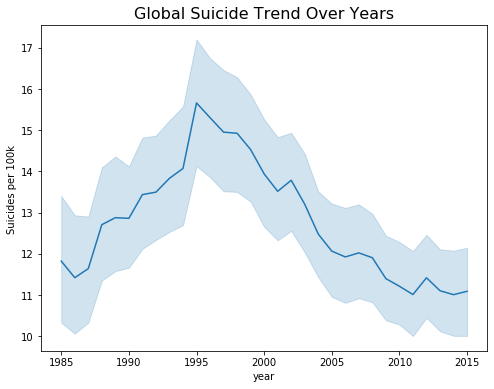

```python
plt.figure(figsize=(8,6))
plt.title('Global Suicide Trend Over Years', fontsize=16)
ys=sb.lineplot(data=df, x='year', y='suicides/100k pop')
ys.set(xlabel='year', ylabel='Suicides per 100k ');
```

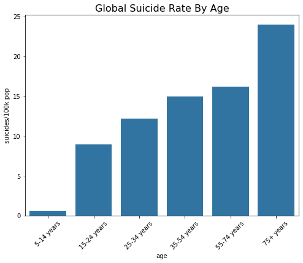

```python
plt.figure(figsize=(8,6))
plt.title('Global Suicide Rate By Age', fontsize=16)
base_color = sb.color_palette()[0]
age_order = ['5-14 years', '15-24 years', '25-34 years', '35-54 years', '55-74 years','75+ years']
chart=sb.barplot(data = df ,x = 'age',y = 'suicides/100k pop', ci = None, color = base_color, order= age_order)
chart.set_xticklabels(chart.get_xticklabels(), rotation=45);
```

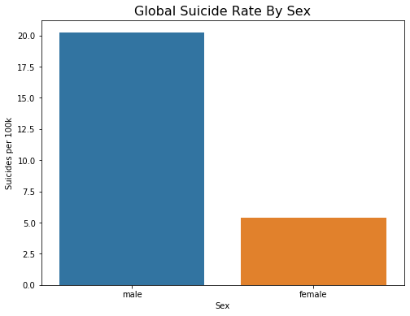

```python
plt.figure(figsize=(8,6))
plt.title('Global Suicide Rate By Sex', fontsize=16)
sx =sb.barplot(data = df ,x = 'sex',y = 'suicides/100k pop' ,ci = None)
sx.set(xlabel='Sex', ylabel='Suicides per 100k');
```

> - The rate of male suicides are three times of female suicide rate.

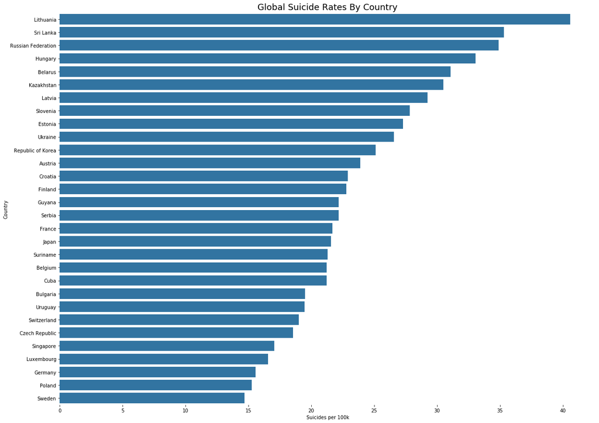

```python
country = df.loc[:,['country','suicides/100k pop']]
country = country.groupby('country')['suicides/100k pop'].mean().reset_index()
country = country.sort_values('suicides/100k pop', ascending=False)
country = country.head(30)
plt.figure(figsize=(20,15))
plt.title('Global Suicide Rates By Country', fontsize=18)
base_color= base_color = sb.color_palette()[0]
chart=sb.barplot(data = country ,x = 'suicides/100k pop',y = 'country', color= base_color)
chart.set(xlabel='Suicides per 100k', ylabel='Country')
sb.despine(left=True, bottom=True);
```

Clearly Lithuania has the highest suicide rate (41 suicides per 100k)

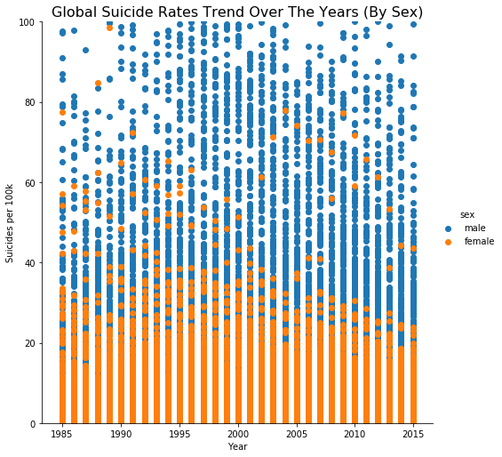

```python
g = sb.FacetGrid(data = df, hue = 'sex', height = 7)
g.map(plt.scatter, 'year','suicides/100k pop')
g.set(xscale = 'log')
x_ticks = [1985, 1990, 1995, 2000, 2005, 2010, 2015]
g.set(xticks = x_ticks, xticklabels = x_ticks)
plt.title('Global Suicide Rates Trend Over The Years (By Sex)', fontsize=16)
g.set(xlabel='Year', ylabel='Suicides per 100k')
plt.ylim([0,100])
g.add_legend();
```

> - During The 80s, the rate for both male and female were low.
> - In the mid of 90s and after the male rate increased.

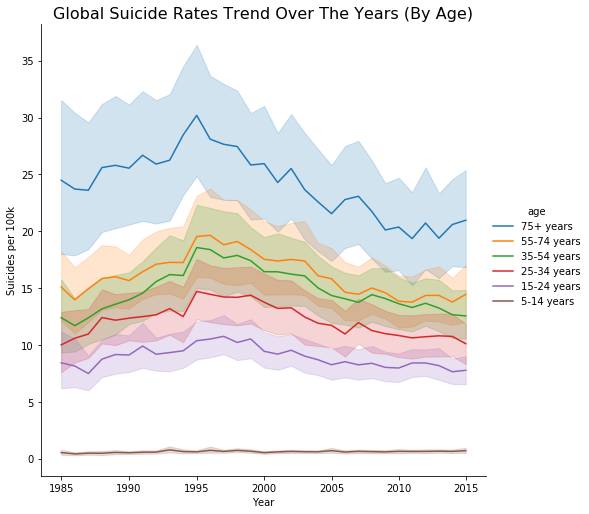

```python
g = sb.FacetGrid(data = df, hue = 'age', height = 7,  hue_order=['75+ years', '55-74 years', '35-54 years', '25-34 years', '15-24 years','5-14 years'])
g.map(sb.lineplot, 'year','suicides/100k pop')
g.set(xscale = 'log')
x_ticks = [1985, 1990, 1995, 2000, 2005, 2010, 2015]
g.set(xticks = x_ticks, xticklabels = x_ticks)
plt.title('Global Suicide Rates Trend Over The Years (By Age)', fontsize=16)
g.set(xlabel='Year', ylabel='Suicides per 100k')
g.add_legend();
```

- The Suicide rate for individuals above 75+ has dropped since 1995.
- Suicide rate for children under 14 remains very consistent and small.